# Tugas Praktikum 2 MPDW

David Fauzan Akmal

2024-09-02

# Pemanggilan *Packages*

```r
library(dplyr)
library(TTR)
library(forecast)
library(readxl)
library(lmtest) #digunakan untuk uji formal pendeteksian autokorelasi
library(orcutt) #untuk membuat model regresi Cochrane-Orcutt
library(HoRM) #untuk membuat model regresi Hildreth-Lu
```

# Input Data

Data yang digunakan dalam kesempatan kali ini adalah data GDP Negara Portugal periode tahun 1960-2023.

```r
dtPortugal <- read_excel("C://Users/USER/Downloads/Data Portugal.xlsx")
dtPortugal <-dtPortugal[1:64,1:2]
```

# Eksplorasi Data

Sebelum melakukan regresi, akan diperlihatkan *plot time-series* dari GDP Negara Portugal periode tahun 1960-2023.

```r
#Membentuk objek time series
data.ts<-ts(dtPortugal$GDP)
data.ts
```

```
## Time Series:
## Start = 1
## End = 64
## Frequency = 1
##  [1]   3339150158   3573719085   3835883663   4084251593   4429202657
##  [6]   4901711248   5370108031   6002607030   6644693214   7287555035
## [11]   8108235704   9201604240  11239117865  15090564186  17512391476
## [16]  19347607843  20332831565  21439523311  23487614051  26622819672
## [21]  32896519824  31977276873  30527754793  27239650742  25217969050
## [26]  27115807742  38745901354  48182925857  56347250696  60594092182
## [31]  78713860217  89233599278 107592098307  95009751901  99688641304
## [36] 118122007430 122630089680 117016535163 123946327916 127470385557
## [41] 118605192877 121604107165 134795565549 165226175537 189382122532
## [46] 197253876705 208756449276 240496147317 263416394624 244667762836
## [51] 238113003233 245117990242 216224240578 226433858006 229901964222
## [56] 199394066525 206426152309 221357874719 242313116578 239986922639
## [61] 229031860521 255534839406 255196659934 287080013574
```

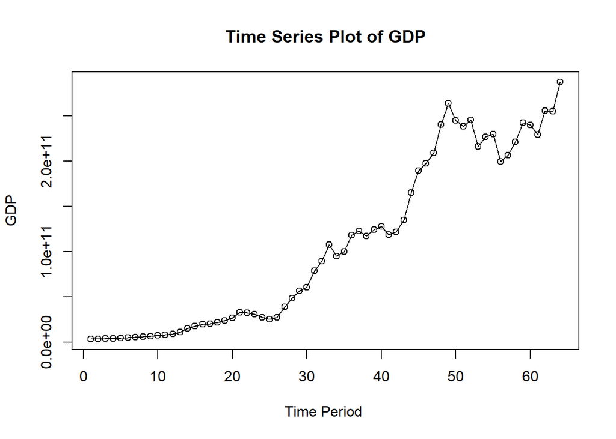

```r
#Membuat plot time series
ts.plot(data.ts, xlab="Time Period ", ylab="GDP", main= "Time Series Plot of GDP")
points(data.ts)
```

Selanjutnya akan dilakukan ramalan dan pemulusan dengan metode DMA dan DES karena terlihat pada plot di atas menunjukkan adanya *trend*.

```r
dt.sma <- SMA(data.ts, n=3)
dma <- SMA(dt.sma, n = 3)
At <- 2*dt.sma - dma
Bt <- 2/(3-1)*(dt.sma - dma)
dt.dma<- At+Bt
dt.ramal<- c(NA, dt.dma)

t = 1:5
f = c()

for (i in t) {
  f[i] = At[length(At)] + Bt[length(Bt)]*(i)
}
```

```r
dt.gab <- cbind(aktual = c(data.ts,rep(NA,5)),
                pemulusan1 = c(dt.sma,rep(NA,5)),
                pemulusan2 = c(dt.dma, rep(NA,5)),
                At = c(At, rep(NA,5)),
                Bt = c(Bt,rep(NA,5)),
                ramalan = c(dt.ramal, f[-1]))
dt.gab
```

```
##             aktual   pemulusan1   pemulusan2           At          Bt
##  [1,]   3339150158           NA           NA           NA          NA
##  [2,]   3573719085           NA           NA           NA          NA
##  [3,]   3835883663   3582917635           NA           NA          NA
##  [4,]   4084251593   3831284780           NA           NA          NA
##  [5,]   4429202657   4116445971   4662238989   4389342480   272896509
##  [6,]   4901711248   4471721833   5135530442   4803626137   331904305
##  [7,]   5370108031   4900340645   5708682970   5304511808   404171162
##  [8,]   6002607030   5424808770   6409845477   5917327123   492518354
##  [9,]   6644693214   6005802758   7130106826   6567954792   562152034
## [10,]   7287555035   6644951760   7884479754   7264715757   619763997
## [11,]   8108235704   7346827985   8708762285   8027795135   680967150
## [12,]   9201604240   8199131660   9803454044   9001292852   802161192
## [13,]  11239117865   9516319270  11840771867  10678545568  1162226298
## [14,]  15090564186  11843762097  15825144274  13834453185  1990691088
```

[output cut: 125 more lines]

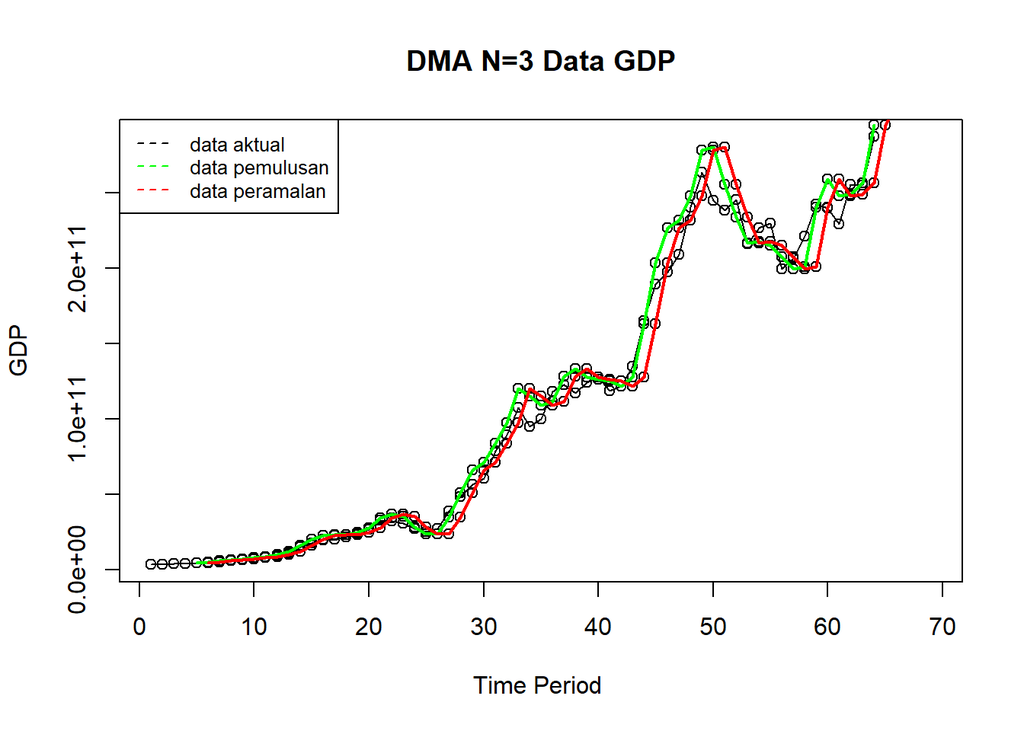

```r
#Plot time series
ts.plot(dt.gab[,1], xlab="Time Period ", ylab="GDP",
        main= "DMA N=3 Data GDP")
points(dt.gab[,1])
points(dt.gab[,3])
points(dt.gab[,6])
lines(dt.gab[,3],col="green",lwd=2)
lines(dt.gab[,6],col="red",lwd=2)
legend("topleft",c("data aktual","data pemulusan","data peramalan"),
       lty=8, col=c("black","green","red"), cex=0.8)
```

Selanjutnya akan dilihat keakuratan dari metode DMA

```r
#Menghitung nilai keakuratan
error.dma = data.ts-dt.ramal[1:length(data.ts)]
SSE.dma = sum(error.dma[6:length(data.ts)]^2)
MSE.dma = mean(error.dma[6:length(data.ts)]^2)
MAPE.dma = mean(abs((error.dma[6:length(data.ts)]/data.ts[6:length(data.ts)])*100))

akurasi.dma <- matrix(c(SSE.dma, MSE.dma, MAPE.dma))
row.names(akurasi.dma)<- c("SSE", "MSE", "MAPE")
colnames(akurasi.dma) <- c("Akurasi m = 3")
akurasi.dma
```

```
##      Akurasi m = 3
## SSE   1.312663e+22
## MSE   2.224853e+20
## MAPE  9.918234e+00
```

Selanjutnya akan digunakan metode *Double Exponential Smoothing* dengan cara sebagai berikut.

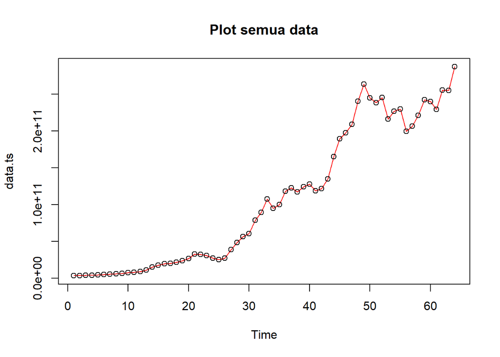

```r
#membagi training dan testing
training<-dtPortugal[1:53,2]
testing<-dtPortugal[54:64,2]

#data time series
training.ts<-ts(training)
testing.ts<-ts(testing,start=54)

#eksplorasi data
plot(data.ts, col="red",main="Plot semua data")
points(data.ts)
```

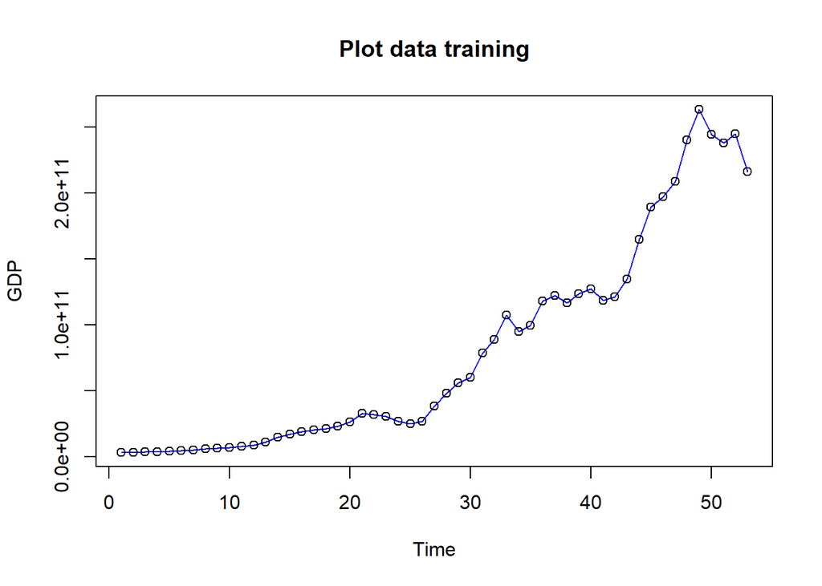

```r
plot(training.ts, col="blue",main="Plot data training")
points(training.ts)
```

Selanjutnya akan dilakukan pemulusan dengan DES, kali ini langsung dicari lambda dan gamma optimum sebagai berikut. Nilai lambda dan gamma optimum dapat dilihat pada smoothing parameters alpha untuk nilai lambda dan beta untuk nilai gamma.

```r
#Lamda dan gamma optimum
des.opt<- HoltWinters(training.ts, gamma = FALSE)
des.opt
```

```
## Holt-Winters exponential smoothing with trend and without seasonal component.
##
## Call:
## HoltWinters(x = training.ts, gamma = FALSE)
##
## Smoothing parameters:
##  alpha: 1
##  beta : 0.07116444
##  gamma: FALSE
##
## Coefficients:
##           [,1]
## a 216224240578
## b   4595408175
```

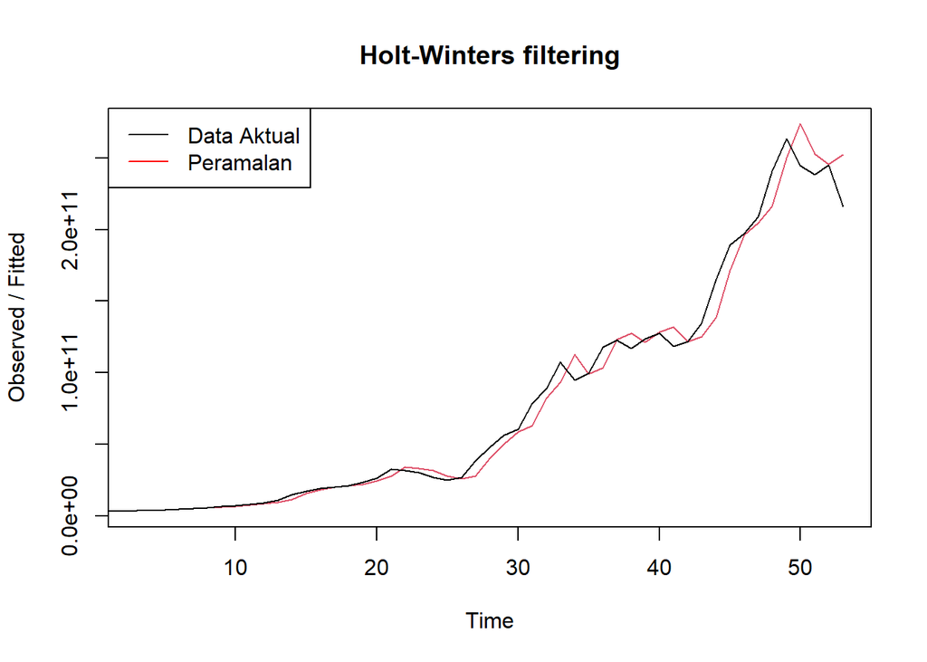

```r
plot(des.opt)
legend("topleft", c("Data Aktual", "Peramalan"), col = c("black", "red"),
       lty = c(1,1))
```

```r
#ramalan
ramalandesopt<- forecast(des.opt, h=5)
ramalandesopt
```

```
##    Point Forecast        Lo 80        Hi 80        Lo 95        Hi 95
## 54   220819648753 206998628189 234640669317 199682221853 241957075652
## 55   225415056928 205161751782 245668362073 194440299672 256389814183
## 56   230010465102 204330471318 255690458886 190736303771 269284626434
## 57   234605873277 203934183648 265277562906 187697571938 281514174616
## 58   239201281452 203761155009 274641407895 185000285329 293402277575
```

Selanjutnya akan dicari akurasi dari metode DES.

```r
ssedes.train<-des.opt$SSE
msedes.train<-ssedes.train/length(training.ts)
sisaandes<-ramalandesopt$residuals
head(sisaandes)
```

```
## Time Series:
## Start = 1
## End = 6
## Frequency = 1
##              x
## [1,]        NA
## [2,]        NA
## [3,]  27595652
## [4,]  11835174
## [5,] 107576065
## [6,] 227478001
```

```r
mapedes.train <- sum(abs(sisaandes[3:length(training.ts)]/training.ts[3:length(training.ts)])*100)/length(training.ts)

akurasides.opt <- matrix(c(ssedes.train,msedes.train,mapedes.train))
row.names(akurasides.opt)<- c("SSE", "MSE", "MAPE")
colnames(akurasides.opt) <- c("Akurasi lamda dan gamma optimum")
akurasides.opt
```

```
##      Akurasi lamda dan gamma optimum
## SSE                     5.889008e+21
## MSE                     1.111134e+20
## MAPE                    7.709425e+00
```

```r
#Akurasi data testing
selisihdesopt<-ramalandesopt$mean-testing.ts
selisihdesopt
```

```
## Time Series:
## Start = 54
## End = 58
## Frequency = 1
##       testing.ts
## [1,] -5614209253
## [2,] -4486907294
## [3,] 30616398577
## [4,] 28179720968
## [5,] 17843406733
```

```r
SSEtestingdesopt<-sum(selisihdesopt^2)
SSEtestingdesopt<-SSEtestingdesopt/length(testing.ts)
MAPEtestingdesopt<-sum(abs(selisihdesopt/testing.ts)*100)/length(testing.ts)

akurasiDesTesting <- matrix(c(SSEtestingdesopt,SSEtestingdesopt,MAPEtestingdesopt))
row.names(akurasiDesTesting)<- c("SSE", "MSE", "MAPE")
colnames(akurasiDesTesting) <- c("Akurasi lamda dan gamma optimum")
akurasiDesTesting
```

```
##      Akurasi lamda dan gamma optimum
## SSE                     1.910454e+20
## MSE                     1.910454e+20
## MAPE                    3.772537e+00
```

Setelah didapatkan nilai akurasi untuk metode DMA dan DES, selanjutnya akan dibandingkan keakuratan antar metode keduanya.

```r
cbind(akurasi.dma, akurasides.opt)
```

```
##      Akurasi m = 3 Akurasi lamda dan gamma optimum
## SSE   1.312663e+22                    5.889008e+21
## MSE   2.224853e+20                    1.111134e+20
## MAPE  9.918234e+00                    7.709425e+00
```

Berdasarkan perbandingan akurasi tersebut, terlihat nilai SSE, MSE, dan MAPE metode DES lebih kecil dibandingkan dengan metode DMA. Oleh karena itu, metode peramalan dan pemulusan yang terbaik antara keduanya adalah dengan metode DES.

Setelah melakukan peramalan, data yang telah dimasukkan kemudian dieksplorasi. Eksplorasi pertama yang dilakukan adalah dengan menggunakan *scatter plot*.

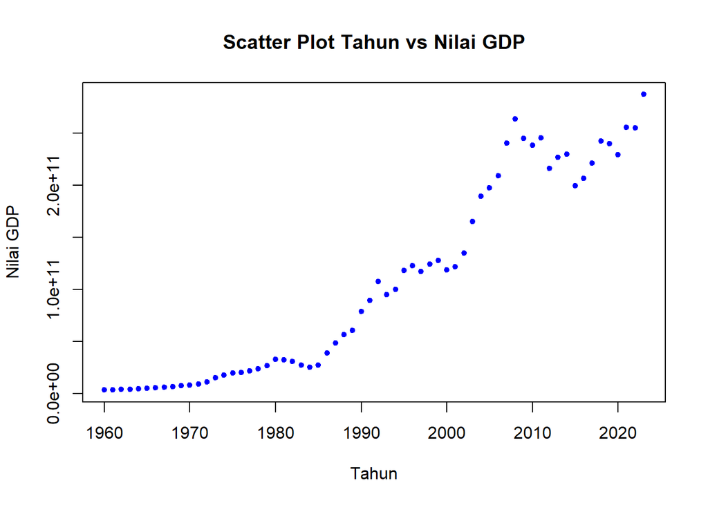

```r
#Eksplorasi Data
#Pembuatan Scatter Plot
plot(dtPortugal$Tahun,dtPortugal$GDP, pch = 20, col = "blue",
     main = "Scatter Plot Tahun vs Nilai GDP",
     xlab = "Tahun",
     ylab = "Nilai GDP")
```

```r
#Menampilkan Nilai Korelasi
cor(dtPortugal$Tahun, dtPortugal$GDP)
```

```
## [1] 0.9554315
```

Berdasarkan scatter plot di atas, terlihat adanya hubungan / korelasi positif antara peubah tahun dengan nilai GDP, terlihat titik-titik pada plot yang naik ke arah kanan atas. Hal tersebut juga diperkuat dengan hasil perhitungan aplikasi `R` di mana didapatkan nilai korelasi sebesar $0.9554315$.

Setalah mengetahui adanya hubungan antar dua peubah, maka model regresi dapat ditentukan.

# Regresi

```r
#Pembuatan Model Regresi
#model regresi
model<- lm(dtPortugal$GDP~dtPortugal$Tahun, data = dtPortugal)
summary(model)
```

```
##
## Call:
## lm(formula = dtPortugal$GDP ~ dtPortugal$Tahun, data = dtPortugal)
##
## Residuals:
##        Min         1Q     Median         3Q        Max
## -4.845e+10 -1.961e+10 -3.416e+09  1.877e+10  7.615e+10
##
## Coefficients:
##                    Estimate Std. Error t value Pr(>|t|)
## (Intercept)      -9.564e+12  3.795e+11  -25.20   <2e-16 ***
## dtPortugal$Tahun  4.856e+09  1.906e+08   25.48   <2e-16 ***
## ---
## Signif. codes:  0 '***' 0.001 '**' 0.01 '*' 0.05 '.' 0.1 ' ' 1
##
## Residual standard error: 2.816e+10 on 62 degrees of freedom
## Multiple R-squared:  0.9128, Adjusted R-squared:  0.9114
## F-statistic: 649.4 on 1 and 62 DF,  p-value: < 2.2e-16
```

Model yang dihasilkan adalah
$$y_i=-9564000000000 + 4856000000x_t$$
Berdasarkan ringkasan model dapat diketahui bahwa hasil uji F memiliki *p-value* < $\alpha$ (5%). Artinya, minimal terdapat satu variabel yang berpengaruh nyata terhadap model. Hasil uji-t parsial kedua parameter regresi, yaitu intersep dan koefisien regresi juga menunjukkan hal yang sama, yaitu memiliki *p-value* < $\alpha$ (5%) sehingga nyata dalam taraf 5%. Selanjutnya dapat dilihat juga nilai $R^2=0.9114$. Artinya, sebesar 91.14% keragaman nilai GDP dapat dijelaskan oleh peubah tahun. Hasil ini menunjukkan hasil yang bagus, seolah mendapatkan hasil terbaik. Namun, kita perlu melakukan uji terhadap sisaannya seperti berikut ini.

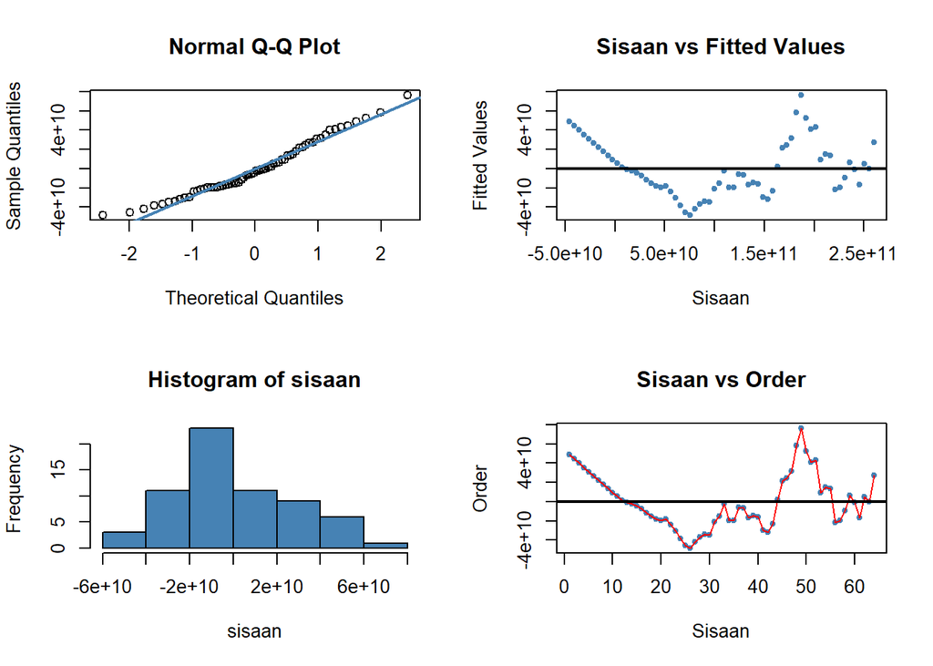

```r
#sisaan dan fitted value
sisaan<- residuals(model)
fitValue<- predict(model)

#Diagnostik dengan eksploratif
par(mfrow = c(2,2))
qqnorm(sisaan)
qqline(sisaan, col = "steelblue", lwd = 2)
plot(fitValue, sisaan, col = "steelblue", pch = 20, xlab = "Sisaan", ylab = "Fitted Values", main = "Sisaan vs Fitted Values")
abline(a = 0, b = 0, lwd = 2)
hist(sisaan, col = "steelblue")
plot(seq_along(sisaan), sisaan, col = "steelblue", pch = 20, xlab = "Sisaan", ylab = "Order", main = "Sisaan vs Order")
lines(seq_along(sisaan), sisaan, col = "red")
abline(a = 0, b = 0, lwd = 2)
```

Dua plot di samping kiri digunakan untuk melihat apakah sisaan menyebar normal. Normal Q-Q Plot di atas menunjukkan bahwa sisaan cenderung menyebar normal. Namun, terdapat beberapa penyimpangan kecil di ujung, yang menunjukkan bahwa residual tidak sepenuhnya mengikuti distribusi normal. Histogram dari sisaan menunjukkan distribusinya tampak tidak simetris dan sedikit miring, yang mengindikasikan bahwa residual tidak sepenuhnya normal. Selanjutnya, dua plot di samping kanan digunakan untuk melihat autokorelasi. Plot Sisaan vs *Fitted Value* dan Plot Sisaan vs *Order* menunjukkan adanya pola pada sisaan. Untuk lebih lanjut akan digunakan uji formal melihat normalitas sisaan dan plot ACF dan PACF untuk melihat apakah ada autokorelasi atau tidak.

```r
#Melihat Sisaan Menyebar Normal/Tidak
#H0: sisaan mengikuti sebaran normal
#H1: sisaan tidak mengikuti sebaran normal
shapiro.test(sisaan)
```

```
##
##  Shapiro-Wilk normality test
##
## data:  sisaan
## W = 0.96857, p-value = 0.1019
```

```r
ks.test(sisaan, "pnorm", mean=mean(sisaan), sd=sd(sisaan))
```

```
##
##  Exact one-sample Kolmogorov-Smirnov test
##
## data:  sisaan
## D = 0.1075, p-value = 0.4207
## alternative hypothesis: two-sided
```

Berdasarkan uji formal Saphiro-Wilk dan Kolmogorov-Smirnov didapatkan nilai *p-value* > $\alpha$ (5%). Artinya, cukup bukti untuk menyatakan sisaan berdistribusi normal.

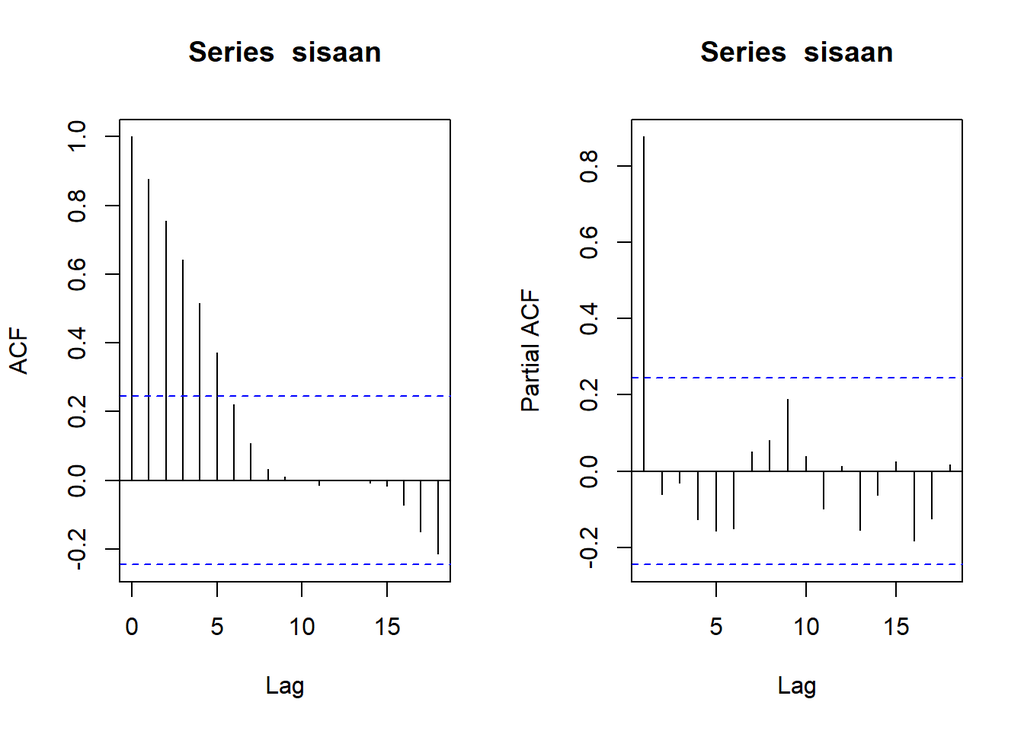

```r
#ACF dan PACF identifikasi autokorelasi
par(mfrow = c(1,2))
acf(sisaan)
pacf(sisaan)
```

```r
#Deteksi autokorelasi dengan uji-Durbin Watson
#H0: tidak ada autokorelasi
#H1: ada autokorelasi
dwtest(model)
```

```
##
##  Durbin-Watson test
##
## data:  model
## DW = 0.18172, p-value < 2.2e-16
## alternative hypothesis: true autocorrelation is greater than 0
```

Berdasarkan hasil DW Test, didapatkan nilai $DW = 0.18172$ dan *p-value* = $2.2e-16$. Berdasarkan tabel Durbin-Watson, dengan 64 observasi dan 1 peubah penjelas diperoleh nilai $DL = 1.5635$ dan $DU = 1.6268$. Nilai DW berada di bawah nilai DL. Artinya, adanya autokorelasi positif yang signifikan pada residual. Dengan nilai *p-value* < 0.05 dapat disimpulkan bahwa tolak H0, cukup bukti mengatakan adanya autokorelasi. Oleh karena itu, diperlukan penangan autokorelasi. Penanganan yang akan digunakan menggunakan dua metode, yaitu Cochrane-Orcutt dan Hildret-Lu.

# Penanganan Autokorelasi

## Metode Cochrane-Orcutt

Penanganan metode Cochrane-Orcutt dapat dilakukan dengan bantuan packages Orcutt pada aplikasi `R` maupun secara manual. Berikut ini ditampilkan cara menggunakan bantuan `library` *packages* `Orcutt`.

```r
#Penanganan Autokorelasi Cochrane-Orcutt
modelCO<-cochrane.orcutt(model)
modelCO
```

```
## Cochrane-orcutt estimation for first order autocorrelation
##
## Call:
## lm(formula = dtPortugal$GDP ~ dtPortugal$Tahun, data = dtPortugal)
##
##  number of interaction: 15
##  rho 0.892105
##
## Durbin-Watson statistic
## (original):    0.18172 , p-value: 1.106e-27
## (transformed): 1.71032 , p-value: 9.785e-02
##
##  coefficients:
##      (Intercept) dtPortugal$Tahun
##    -1.165383e+13     5.899134e+09
```

Hasil keluaran model setelah dilakukan penanganan adalah sebagai berikut.
$$y_i=-11653830000000 +
5899134000x_t$$
Hasil juga menunjukkan bahwa nilai DW dan p-value meningkat menjadi $1.71032$ dan $0.09785$. Nilai DW sudah berada pada rentang DU < DW < 4-DU atau $1.6268 < DW < 2.3732$. Hal tersebut juga didukung dengan nilai *p-value* > 0.05, artinya belum cukup bukti menyatakan bahwa sisaan terdapat autokorelasi pada taraf nyata 5%. Untuk nilai $ρ ̂$ optimum yang digunakan adalah $0.8921046$. Nilai tersebut dapat diketahui dengan *syntax* berikut.

```r
#Rho optimum
rho<- modelCO$rho
rho
```

```
## [1] 0.8921046
```

Selanjutnya akan dilakukan transformasi secara manual dengan syntax berikut ini.

```r
dtPortugal$GDP
```

```
##  [1]   3339150158   3573719085   3835883663   4084251593   4429202657
##  [6]   4901711248   5370108031   6002607030   6644693214   7287555035
## [11]   8108235704   9201604240  11239117865  15090564186  17512391476
## [16]  19347607843  20332831565  21439523311  23487614051  26622819672
## [21]  32896519824  31977276873  30527754793  27239650742  25217969050
## [26]  27115807742  38745901354  48182925857  56347250696  60594092182
## [31]  78713860217  89233599278 107592098307  95009751901  99688641304
## [36] 118122007430 122630089680 117016535163 123946327916 127470385557
## [41] 118605192877 121604107165 134795565549 165226175537 189382122532
## [46] 197253876705 208756449276 240496147317 263416394624 244667762836
## [51] 238113003233 245117990242 216224240578 226433858006 229901964222
## [56] 199394066525 206426152309 221357874719 242313116578 239986922639
## [61] 229031860521 255534839406 255196659934 287080013574
```

```r
dtPortugal$GDP[-1]
```

```
##  [1]   3573719085   3835883663   4084251593   4429202657   4901711248
##  [6]   5370108031   6002607030   6644693214   7287555035   8108235704
## [11]   9201604240  11239117865  15090564186  17512391476  19347607843
## [16]  20332831565  21439523311  23487614051  26622819672  32896519824
## [21]  31977276873  30527754793  27239650742  25217969050  27115807742
## [26]  38745901354  48182925857  56347250696  60594092182  78713860217
## [31]  89233599278 107592098307  95009751901  99688641304 118122007430
## [36] 122630089680 117016535163 123946327916 127470385557 118605192877
## [41] 121604107165 134795565549 165226175537 189382122532 197253876705
## [46] 208756449276 240496147317 263416394624 244667762836 238113003233
## [51] 245117990242 216224240578 226433858006 229901964222 199394066525
## [56] 206426152309 221357874719 242313116578 239986922639 229031860521
## [61] 255534839406 255196659934 287080013574
```

```r
#Transformasi Manual
gdp.trans<- dtPortugal$GDP[-1]-dtPortugal$GDP[-64]*rho
tahun.trans<- dtPortugal$Tahun[-1]-dtPortugal$Tahun[-64]*rho
modelCOmanual<- lm(gdp.trans~tahun.trans)
summary(modelCOmanual)
```

```
##
## Call:
## lm(formula = gdp.trans ~ tahun.trans)
##
## Residuals:
##        Min         1Q     Median         3Q        Max
## -3.610e+10 -4.603e+09  5.443e+06  4.234e+09  2.896e+10
##
## Coefficients:
##               Estimate Std. Error t value Pr(>|t|)
## (Intercept) -1.257e+12  1.595e+11  -7.883 6.99e-11 ***
## tahun.trans  5.899e+09  7.390e+08   7.982 4.72e-11 ***
## ---
## Signif. codes:  0 '***' 0.001 '**' 0.01 '*' 0.05 '.' 0.1 ' ' 1
##
## Residual standard error: 1.151e+10 on 61 degrees of freedom
## Multiple R-squared:  0.5109, Adjusted R-squared:  0.5029
## F-statistic: 63.72 on 1 and 61 DF,  p-value: 4.718e-11
```

```r
#Mencari Penduga Koefisien Regresi setelah Transformasi ke Persamaan Awal
b0bintang <- modelCOmanual$coefficients[-2]
b0 <- b0bintang/(1-rho)
b1 <- modelCOmanual$coefficients[-1]
b0
```

```
##   (Intercept)
## -1.165383e+13
```

```r
b1
```

```
## tahun.trans
##  5899133526
```

Hasil perhitungan koefisien regresi tersebut akan menghasilkan hasil yang sama dengan model yang dihasilkan menggunakan *packages*.

## Metode Hildreth-Lu

Penanganan kedua adalah menggunakan metode Hildreth-Lu. Metode ini akan mencari nilai SSE terkecil dan dapat dicari secara manual maupun menggunakan packages. Jika menggunakan packages, gunakan `library` *packages* `HORM`.

```r
#Penanganan Autokorelasi Hildreth lu
# Hildreth-Lu
hildreth.lu.func<- function(r, model){
  x <- model.matrix(model)[,-1]
  y <- model.response(model.frame(model))
  n <- length(y)
  t <- 2:n
  y <- y[t]-r*y[t-1]
  x <- x[t]-r*x[t-1]

  return(lm(y~x))
}

#Pencariab rho yang meminimumkan SSE
r <- c(seq(0.1,1, by= 0.1))
tab <- data.frame("rho" = r, "SSE" = sapply(r, function(i){deviance(hildreth.lu.func(i, model))}))
round(tab, 4)
```

```
##    rho          SSE
## 1  0.1 3.844711e+22
## 2  0.2 3.126354e+22
## 3  0.3 2.504797e+22
## 4  0.4 1.980039e+22
## 5  0.5 1.552082e+22
## 6  0.6 1.220925e+22
## 7  0.7 9.865673e+21
## 8  0.8 8.490100e+21
## 9  0.9 8.082528e+21
## 10 1.0 8.928039e+21
```

```r
#Rho optimal di sekitar 0.4
rOpt <- seq(0.7,1, by= 0.001)
tabOpt <- data.frame("rho" = rOpt, "SSE" = sapply(rOpt, function(i){deviance(hildreth.lu.func(i, model))}))
head(tabOpt[order(tabOpt$SSE),])
```

```
##       rho          SSE
## 193 0.892 8.079511e+21
## 194 0.893 8.079549e+21
## 192 0.891 8.079570e+21
## 195 0.894 8.079684e+21
## 191 0.890 8.079725e+21
## 196 0.895 8.079916e+21
```

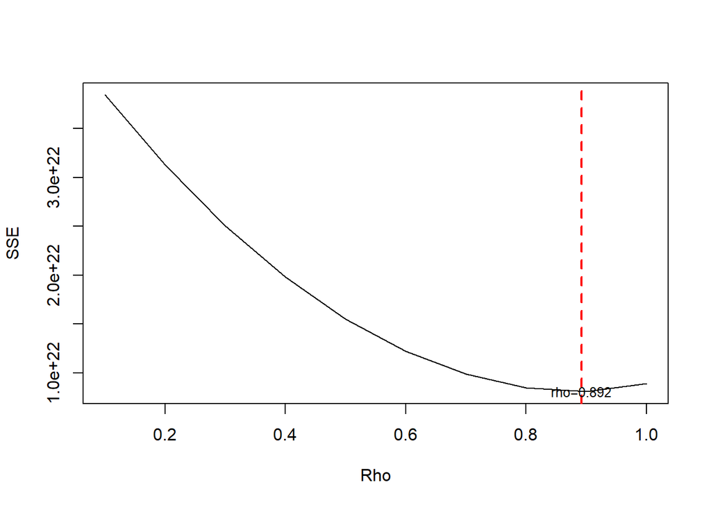

```r
#Grafik SSE optimum
par(mfrow = c(1,1))
plot(tab$SSE ~ tab$rho , type = "l", xlab = "Rho", ylab = "SSE")
abline(v = tabOpt[tabOpt$SSE==min(tabOpt$SSE),"rho"], lty = 2, col="red",lwd=2)
text(x=0.892, y=8.079511e+21, labels = "rho=0.892", cex = 0.8)
```

Perhitungan yang dilakukan aplikasi `R` menunjukkan bahwa nilai $ρ$ optimum, yaitu saat SSE terkecil terdapat pada nilai $ρ=0.892$. Hal tersebut juga ditunjukkan pada plot. Selanjutnya, model dapat didapatkan dengan mengevaluasi nilai $ρ$ ke dalam fungsi `hildreth.lu.func`, serta dilanjutkan dengan pengujian autokorelasi dengan uji Durbin-Watson. Namun, setelah pengecekan tersebut tidak lupa koefisien regresi tersebut digunakan untuk transformasi balik. Persamaan hasil transformasi itulah yang menjadi persamaan sesungguhnya.

```r
#Model terbaik
modelHL <- hildreth.lu.func(0.892, model)
summary(modelHL)
```

```
##
## Call:
## lm(formula = y ~ x)
##
## Residuals:
##        Min         1Q     Median         3Q        Max
## -3.609e+10 -4.606e+09  5.571e+06  4.234e+09  2.896e+10
##
## Coefficients:
##               Estimate Std. Error t value Pr(>|t|)
## (Intercept) -1.258e+12  1.595e+11  -7.889 6.82e-11 ***
## x            5.898e+09  7.383e+08   7.989 4.60e-11 ***
## ---
## Signif. codes:  0 '***' 0.001 '**' 0.01 '*' 0.05 '.' 0.1 ' ' 1
##
## Residual standard error: 1.151e+10 on 61 degrees of freedom
## Multiple R-squared:  0.5113, Adjusted R-squared:  0.5033
## F-statistic: 63.82 on 1 and 61 DF,  p-value: 4.601e-11
```

```r
#Transformasi Balik
cat("y = ", coef(modelHL)[1]/(1-0.892), "+", coef(modelHL)[2],"x", sep = "")
```

```
## y = -1.165172e+13+5898083579x
```

Setelah dilakukan tranformasi balik, didapatkan model dengan metode Hildreth-Lu sebagai berikut.
$$y_i=-11651720000000+5898083579x_t$$

```r
#Deteksi autokorelasi
dwtest(modelHL)
```

```
##
##  Durbin-Watson test
##
## data:  modelHL
## DW = 1.7101, p-value = 0.09773
## alternative hypothesis: true autocorrelation is greater than 0
```

Hasil uji Durbin-Watson juga menunjukkan bawah nilai DW sebesar $1.7101$ berada pada selang daerah tidak ada autokorelasi, yaitu pada rentang DU < DW < 4-DU atau $1.6268$ < $DW$ < $2.3732$. Hal tersebut juga didukung oleh *p-value* sebesar $0.09773$, di mana *p-value* > $\alpha$=5%. Artinya tak tolak $H_0$ atau belum cukup bukti menyatakan bahwa ada autokorelasi dalam data nilai GDP dengan metode Hildreth-Lu pada taraf nyata 5%.

Terakhir, akan dibandingkan nilai SSE dari ketiga metode (metode awal, metode Cochrane-Orcutt, dan Hildreth-Lu).

```r
#Perbandingan
sseModelawal <- anova(model)$`Sum Sq`[-1]
sseModelCO <- anova(modelCOmanual)$`Sum Sq`[-1]
sseModelHL <- anova(modelHL)$`Sum Sq`[-1]
mseModelawal <- sseModelawal/length(dtPortugal$GDP)
mseModelCO <- sseModelCO/length(dtPortugal$GDP)
mseModelHL <- sseModelHL/length(dtPortugal$GDP)
akurasi <- matrix(c(sseModelawal,sseModelCO,sseModelHL,
                    mseModelawal,mseModelCO,mseModelHL),nrow=2,ncol=3,byrow = T)
colnames(akurasi) <- c("Model Awal", "Model Cochrane-Orcutt", "Model Hildreth-Lu")
row.names(akurasi) <- c("SSE","MSE")
akurasi
```

```
##       Model Awal Model Cochrane-Orcutt Model Hildreth-Lu
## SSE 4.917488e+22          8.079511e+21      8.079511e+21
## MSE 7.683575e+20          1.262424e+20      1.262424e+20
```

Berdasarkan hasil tersebut dapat diketahui bahwa hasil penanganan autokorelasi dengan metode Cochrane-Orcutt dan Hildreth-Lu memiliki SSE yang sama, sebesar $8.079511e+21$ dan lebih baik dibandingkan model awal ketika autokorelasi masih terjadi, yaitu sebesar $4.917488e+22$.

# Simpulan

Autokorelasi yang terdapat pada data GDP terjadi akibat adanya korelasi di antara unsur penyusunnya. Adanya autokorelasi menyebabkan model regresi kurang baik karena akan meingkatkan galatnya. Autokorelasi dapat dideteksi secara eksploratif melalui plot sisaan, ACF, dan PACF, serta dengan uji formal Durbin-Watson. Namun, autokorelasi tersebut dapat ditangani dengan metode Cochrane-Orcutt dan Hildreth-Lu. Kedua metode menghasilkan nilai SSE yang sama, artinya keduanya baik untuk digunakan.